# Lab 3: Using rstan

(with solutions)

## 1 Exercise

### 1.1 Context

We now return to our previous linear regression example: A regression of AfD support on pro-redistribution and anti-immigration preferences.

We now want to use our posterior draws to generate more complex substantively meaningful quantities of interest: A Bayesian version of the 3D visualization from the take-home exercise.

### 1.2 Data

The object `gles` and the Stan program `lm_mod` are pre-loaded in the exercise chunk below.

Generate all required data inputs and collect them in an appropriately named list that matches the declared names in your Stan `data` block.

Make sure to include `se_self` and `la_self` and the corresponding product term, alongside the following background covariates: `age`, `fem`, and `east`.

```r
# Define data
y <- gles$sup_afd
x <- model.matrix( ~ se_self +
                     la_self +
                     se_self:la_self +
                     age +
                     fem +
                     east,
                   data = gles)
N <- nrow(x)
K <- ncol(x)

# Data as list
standat <- list(
  N = N,
  K = K,
  x = x,
  y = y
)

# Export newly created objects to global environment
export(environment())
```

```
## Exported objects:
## standat
```

### 1.3 Compilation

Now, compile your Stan program from the (pre-loaded) character string `lm_code`.

```r
lm_mod <- rstan::stan_model(model_code = lm_code)

# Export newly created objects to global environment
export(environment())
```

```
## Exported objects:
## standat
```

### 1.4 Inference

Estimate your model and store the `stanfit` object.

*Note:* The `stanfit` object will be preloaded in the next step, even if you hit a time-out here.

```r
lm_est <- rstan::sampling(
  lm_mod,
  data = standat,
  algorithm = "NUTS",
  pars = c("beta", "sigma"),
  iter = 2000L,
  warmup = 1000L,
  thin = 2L,
  chains = 2L,
  cores = 2L,
  seed = 20210329
)

# Export newly created objects to global environment
export(environment())
```

```
## Exported objects:
## lm_est standat
```

### 1.5 Model summary

Print your model summary and see if `Rhat` shows any signs of non-convergence.

```r
print(lm_est, digits = 3L)
```

```
## Inference for Stan model: anon_model.
## 2 chains, each with iter=2000; warmup=1000; thin=2;
## post-warmup draws per chain=500, total post-warmup draws=1000.
##
##              mean se_mean    sd      2.5%       25%       50%       75%     97.5% n_eff  Rhat
## beta[1]    -3.807   0.016 0.428    -4.644    -4.101    -3.825    -3.514    -2.938   754 1.000
## beta[2]    -0.122   0.002 0.063    -0.248    -0.163    -0.121    -0.077    -0.004   727 0.998
## beta[3]     0.304   0.002 0.054     0.199     0.269     0.305     0.341     0.408   744 0.999
## beta[4]    -0.015   0.000 0.004    -0.023    -0.017    -0.015    -0.012    -0.007  1044 0.999
## beta[5]    -0.589   0.004 0.127    -0.836    -0.674    -0.585    -0.503    -0.346  1045 0.999
## beta[6]     0.421   0.005 0.146     0.127     0.321     0.423     0.521     0.694   914 1.000
## beta[7]     0.012   0.000 0.009    -0.005     0.007     0.012     0.018     0.030   678 0.998
## sigma       2.441   0.002 0.048     2.347     2.409     2.439     2.475     2.532   984 0.999
## lp__    -3077.500   0.077 1.954 -3082.324 -3078.647 -3077.154 -3076.103 -3074.711   637 1.004
##
## Samples were drawn using NUTS(diag_e) at Tue Apr 21 09:14:15 2026.
## For each parameter, n_eff is a crude measure of effective sample size,
## and Rhat is the potential scale reduction factor on split chains (at
## convergence, Rhat=1).
```

### 1.6 Extract your post-warm-up samples

Now, things are about to get interesting.

Extract the posterior draws of your model parameters. Store the draws for `beta` in a separate object. Check the dimensions of that object. What do the rows and columns contain?

```r
beta_draws <- posterior::as_draws_matrix(lm_est) %>%
  posterior::subset_draws(variable = "beta")

str(beta_draws)
```

```
##  'draws_matrix' num [1:1000, 1:7] -3.41 -4.21 -4.18 -4.21 -3.91 ...
##  - attr(*, "dimnames")=List of 2
##   ..$ draw    : chr [1:1000] "1" "2" "3" "4" ...
##   ..$ variable: chr [1:7] "beta[1]" "beta[2]" "beta[3]" "beta[4]" ...
##  - attr(*, "nchains")= int 2
```

```r
# Export newly created objects to global environment
export(environment())
```

```
## Exported objects:
## beta_draws lm_est standat
```

### 1.7 Calculate the full posterior distribution of your quantity of interest

We have 1000 posterior draws of each model coefficient (taken from two chains à 1000 post-warm-up draws thinned by a factor of 2).

Now, we want to use these to obtain the full posterior distribution of our quantity of interest.

For reference, here is how we calculated our quantity of interest in Lab 1:

```r
# Define value sequences
se_vals <- seq(0, 10, .25)
la_vals <- seq(0, 10, .25)

# Initialize container
pred <- array(NA, dim = c(length(se_vals), length(la_vals), 3L))

# Nested loop for point estimates and confidence bounds
for (i in seq_along(se_vals)) {
  for (j in seq_along(la_vals)) {
    x_star <- c(1, se_vals[i], la_vals[j], se_vals[i] * la_vals[j])
    std_err <- sqrt(as.vector(t(x_star) %*% Sigma %*% x_star))
    pred[i, j, 1] <- x_star %*% b
    pred[i, j, 2] <- pred[i, j, 1] + qnorm(.025) * std_err
    pred[i, j, 3] <- pred[i, j, 1] + qnorm(.975) * std_err
  }
}
```

Three things will be different this time around:

1. We do not want point estimates and confidence bounds, but the full posterior. Adjust the dimensions of the container `pred` accordingly.
2. Previously, all elements of `x_star` (except the leading 1) changed at each iteration of the loop. Now, we must hold our background covariates constant at some value, e.g., at their sample mean. Make sure to change the correct elements of `x_star` at each iteration while holding all others constant.
3. Previously `x_star %*% b` was a simple inner product of two $K$-length vectors. Now we must multiply an $S \times K$ matrix ($S$ draws for $K$ coefficients) with a $K$-length vector $x^{\ast}$ (remember that the arguments must be conformable).

Let’s give it a try:

```r
# Define value sequences
se_vals <- seq(0, 10, .25)
la_vals <- seq(0, 10, .25)

# Initialize container
pred <- array(NA, dim = c(length(se_vals),
                          length(la_vals),
                          nrow(beta_draws)))

# Get a template vector of sample means
x_tmp <- apply(x, 2, mean)

# Inspect which element holds which predictor
names(x_tmp)
```

```
## [1] "(Intercept)"     "se_self"         "la_self"         "age"             "fem"
## [6] "east"            "se_self:la_self"
```

```r
# Get the names or indices of elements you want to change
x_index <- c("se_self", "la_self", "se_self:la_self")

# Nested loop for point estimates and confidence bounds
for (i in seq_along(se_vals)) {
  for (j in seq_along(la_vals)) {
    # Copy and modify x
    x_star <- x_tmp
    x_star[x_index] <- c(se_vals[i], la_vals[j], se_vals[i] * la_vals[j])

    ## Store S draws of qoi in pred[i, j, ]
    pred[i, j, ] <- beta_draws %*% x_star
  }
}

# Export newly created objects to global environment
export(environment())
```

```
## Exported objects:
## beta_draws la_vals lm_est pred se_vals standat x_index x_star x_tmp
```

### 1.8 Summarize the posterior distribution of your QOI

The object `pred` now holds $S$ posterior draws for the expected value of AfD Support at each combination of `se_vals` and `la_vals`.

Let’s summarize the posterior distribution. For each expected values, take the 50%, 2.5% and 97.5% percentiles. This is a quantile-based summary of the posterior distribution that gives us the posterior median and the 95% credible interval.

*Hint:* You can use `apply()` on an array, too! Just set the `MARGIN` argument to those dimensions you would like to retain. But beware: The dimensions of the resulting object may be different from what you would intuitively expect.

```r
pred_summary <- apply(pred, 1:2, quantile, c(.5, .025, .975))

# Export newly created objects to global environment
export(environment())
```

```
## Exported objects:
## beta_draws la_vals lm_est pred pred_summary se_vals standat x_index x_star x_tmp
```

### 1.9 Visualization

You guessed it: We can now use `regplane3D::plane3D()` on `pred_summary` to visualize our expected values, much like we did yesterday.

```r
# Change array dimensions to make them compatible with plane3D()
pred_summary <- aperm(pred_summary, perm = c(2, 3, 1))

regplane3D::plane3D(
  z = pred_summary,
  x = se_vals,
  y = la_vals,
  main = "Expected AfD Support \n by Redistribution and Immigration Preferences",
  zlab = "Support AfD",
  xlab = "Pro-Redistribution",
  ylab = "Anti-Immigration",
  xnlines = 6L,
  ynlines = 6L
)
```

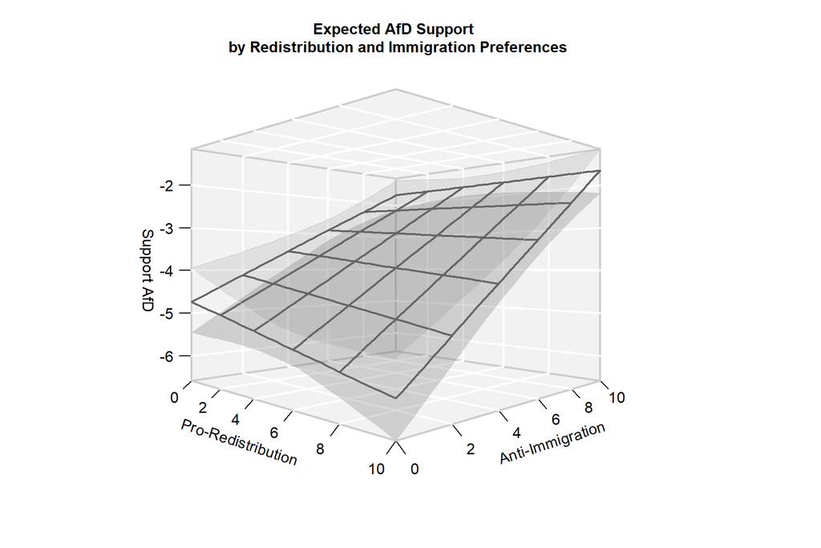